# **TRABALHO FINAL - ETAPA 2 - ÁREA DE DADOS NO BRASIL**

**Integrantes do Grupo:**

- Alexandre Marcelo Marques Filho
- João Victor Tozoni
- Pedro Humberto Bitencourt Nascimento

**Tema:** Percepção de Carreira e Ambiente de Trabalho

**Disciplina:** Análise de Dados IV

**Professor:** José Eduardo

### **Introdução**

O mercado de trabalho em dados no Brasil atingiu um nível de maturidade onde apenas a análise de salários e ferramentas técnicas não é mais suficiente para compreender a dinâmica de retenção e satisfação de talentos. Aspectos subjetivos — como a percepção de progresso, o clima organizacional e o nível de stress — desempenham papéis cruciais na decisão de um profissional permanecer ou não em uma empresa. No entanto, esses aspectos raramente se manifestam de forma isolada; eles compõem uma rede complexa de sentimentos e percepções interligadas.

Para desvendar essa complexidade, utilizamos a Análise Fatorial Exploratória (AFE). Esta é uma técnica estatística multivariada usada para identificar estruturas subjacentes (fatores latentes) em um grande conjunto de variáveis. No contexto desta pesquisa, usamos a AFE para verificar se as diversas perguntas de percepção sobre o trabalho (Satisfação, Stress, Oportunidades) podem ser agrupadas em conceitos macro, reduzindo a dimensionalidade dos dados sem perder informação.

Ao aplicar este método sobre a seção '1.f' do State of Data Brazil 2024, nosso objetivo transcende a estatística descritiva. Buscamos responder: os desafios relatados pelos profissionais são dispersos ou formam padrões claros? Existe uma distinção estrutural entre 'insatisfação com a carreira' e 'problemas de relacionamento'? Ao mapear esses fatores latentes, oferecemos à Gestão da Informação um diagnóstico mais preciso, permitindo que líderes e empresas desenhem estratégias de gestão de pessoas baseadas em evidências (data-driven HR), focando na raiz dos problemas e não apenas em seus sintomas.

.

**Fonte dos Dados**

Os dados utilizados foram extraídos da 5ª edição da pesquisa "State of Data Brazil", conduzida pela Data Hackers em parceria com a Bain & Company. A coleta ocorreu entre 14 de outubro e 18 de dezembro de 2024, com a participação de 5.217 profissionais brasileiros da área de dados.

> Fonte do Dataset: https://www.kaggle.com/datasets/datahackers/state-of-data-brazil-20242025?resource=download

### **Configuração do Ambiente e Estética**

**O que estamos fazendo:** Preparamos o terreno instalando bibliotecas específicas (factor_analyzer) que não são nativas do Python padrão e definindo parâmetros visuais.

**Por que fazer:** A biblioteca factor_analyzer contém os testes robustos (Bartlett, KMO) necessários para validar a análise. Além disso, criamos uma classe utilitária de "Logs" para que a saída do terminal não seja apenas texto preto e branco, mas sim um relatório visualmente agradável, facilitando a leitura dos resultados.

```python
#@title Configuração do Ambiente
!pip install factor_analyzer > /dev/null 2>&1

import pandas as pd
import numpy as np
import seaborn as sns
import matplotlib.pyplot as plt
from factor_analyzer import FactorAnalyzer
from factor_analyzer.factor_analyzer import calculate_bartlett_sphericity
from factor_analyzer.factor_analyzer import calculate_kmo
from IPython.display import display
import warnings

warnings.filterwarnings("ignore")
sns.set_theme(style="whitegrid", context="talk")
plt.rcParams['figure.figsize'] = [12, 7]

class Log:
    HEADER = '\033[1;30m'
    OKBLUE = '\033[94m'
    OKGREEN = '\033[92m'
    WARNING = '\033[93m'
    ENDC = '\033[0m'
    BOLD = '\033[1m'

    @staticmethod
    def title(text):
        print(f"\n{Log.HEADER}{Log.BOLD}{'='*90}{Log.ENDC}")
        print(f"{Log.HEADER}{Log.BOLD}  {text.upper()}{Log.ENDC}")
        print(f"{Log.HEADER}{Log.BOLD}{'='*90}{Log.ENDC}\n")

    @staticmethod
    def section(text):
        print(f"\n{Log.OKBLUE}{Log.BOLD}>>> {text}{Log.ENDC}")

    @staticmethod
    def info(label, value):
        print(f"   • {label}: {Log.BOLD}{value}{Log.ENDC}")

    @staticmethod
    def success(text):
        print(f"   ✅ {Log.OKGREEN}{text}{Log.ENDC}")

Log.success("Ambiente configurado e estilos definidos.")
```

```
   ✅ Ambiente configurado e estilos definidos.
```

### **Carga, Seleção e Tratamento dos Dados**

**O que estamos fazendo:** Carregamos a base de dados, isolamos a seção 1.f (Percepção sobre o trabalho) e convertemos as respostas textuais (ex: "Muito Satisfeito") em escalas numéricas (ex: 5). Também removemos dados ausentes.

**Por que fazer:** A Análise Fatorial depende de uma matriz de correlação, que exige dados numéricos. Textos como "Concordo" não podem ser calculados matematicamente sem essa conversão (escala Likert). A limpeza de nulos é crucial, pois algoritmos de fatorização são sensíveis a dados faltantes. Escolhemos a seção 1.f pois ela contém variáveis ordinais que medem sentimentos e percepções, ideais para descobrir construtos latentes.

```python
#@title 1. Preparação e Tratamento da Amostra
Log.title("1. Preparação e Tratamento da Amostra")
try:
    df = pd.read_csv('Final Dataset - State of Data 2024 - Kaggle - df_survey_2024.csv')
    Log.section("Leitura do Arquivo")
    Log.info("Dataset carregado", "State of Data 2024")
except:
    Log.alert("Erro ao ler arquivo. Verifique se o CSV está no Colab.")
cols_afe = [c for c in df.columns if c.startswith('1.f.')]
df_afe = df[cols_afe].copy()
scale_map = {
    'Muito satisfeito': 5, 'Satisfeito': 4, 'Neutro': 3, 'Insatisfeito': 2, 'Muito insatisfeito': 1,
    'Concordo totalmente': 5, 'Concordo': 4, 'Discordo': 2, 'Discordo totalmente': 1,
    'Muito alto': 5, 'Alto': 4, 'Médio': 3, 'Baixo': 2, 'Muito baixo': 1,
    'Muito alta': 5, 'Alta': 4, 'Média': 3, 'Baixa': 2, 'Muito baixa': 1,
    'Sim': 1, 'Não': 0,
    'Não sei opinar': np.nan, 'Não se aplica': np.nan
}
Log.section("Conversão de Escalas (Texto -> Número)")
for col in df_afe.columns:
    if df_afe[col].dtype == 'object':
        df_afe[col] = df_afe[col].map(scale_map)
n_original = len(df_afe)
df_afe.dropna(inplace=True)
n_final = len(df_afe)
Log.section("Relatório de Amostragem")
Log.info("Variáveis analisadas", len(cols_afe))
Log.info("Respondentes válidos", n_final)
ratio = n_final / len(cols_afe)

if ratio > 10:
    Log.success(f"Razão de {ratio:.1f} respondentes por variável (Recomendado: >10:1). Amostra robusta.")
else:
    Log.alert(f"Razão de {ratio:.1f} é baixa. Cuidado com a generalização.")
print("\n")
display(df_afe.head().T.style.background_gradient(cmap='Blues', axis=None).format("{:.0f}"))
```

```
==========================================================================================
  1. PREPARAÇÃO E TRATAMENTO DA AMOSTRA
==========================================================================================


>>> Leitura do Arquivo
   • Dataset carregado: State of Data 2024

>>> Conversão de Escalas (Texto -> Número)

>>> Relatório de Amostragem
   • Variáveis analisadas: 9
   • Respondentes válidos: 1289
   ✅ Razão de 143.2 respondentes por variável (Recomendado: >10:1). Amostra robusta.
```

|  | 10 | 14 | 15 | 16 | 21 |
| --- | --- | --- | --- | --- | --- |
| 1.f.1_Quantidade de oportunidades de emprego/vagas recebidas | 1 | 1 | 0 | 1 | 1 |
| 1.f.2_Senioridade das vagas recebidas em relação à sua experiência | 0 | 0 | 0 | 0 | 0 |
| 1.f.3_Aprovação em processos seletivos/entrevistas | 1 | 1 | 0 | 0 | 1 |
| 1.f.4_Oportunidades de progressão de carreira | 0 | 0 | 0 | 0 | 1 |
| 1.f.5_Velocidade de progressão de carreira | 1 | 0 | 0 | 0 | 1 |
| 1.f.6_Nível de cobrança no trabalho/Stress no trabalho | 0 | 0 | 0 | 0 | 1 |
| 1.f.7_Atenção dada pelas pessoas diante das minhas opiniões e ideias | 0 | 0 | 1 | 0 | 0 |
| 1.f.8_Relação com outras pessoas da empresa, em momentos de trabalho | 0 | 0 | 0 | 0 | 0 |
| 1.f.9_Relação com outras pessoas da empresa, em momentos de integração e outros momentos fora do trabalho | 0 | 0 | 1 | 0 | 0 |

### **Verificação de Pressupostos (Fatorabilidade)**

**O que estamos fazendo:** Aplicamos dois testes estatísticos fundamentais: o Teste de Esfericidade de Bartlett e o critério KMO (Kaiser-Meyer-Olkin).

**Por que fazer:** Antes de extrair fatores, precisamos provar que os dados podem ser fatorados.

- **Bartlett:** Testa se as variáveis têm correlação entre si. Se não tiverem (p > 0.05), a AFE é inútil. Queremos p < 0.05.
- **KMO:** Mede a adequação da amostra. Se for baixo (< 0.6), indica que as correlações são difusas e não formam grupos coesos. Queremos KMO próximo de 1.0.

```python
#@title 2. Verificação de Pressupostos (Fatorabilidade)
Log.title("2. Verificação de Pressupostos (Fatorabilidade)")

chi_square, p_value = calculate_bartlett_sphericity(df_afe)
kmo_all, kmo_model = calculate_kmo(df_afe)
df_tests = pd.DataFrame({
    'Teste Estatístico': ['Esfericidade de Bartlett (p-valor)', 'KMO Global (Adequação da Amostra)'],
    'Valor Calculado': [p_value, kmo_model],
    'Valor de Referência': ['< 0.05', '> 0.60'],
    'Status': ['Aprovado' if p_value < 0.05 else 'Reprovado',
               'Excelente' if kmo_model > 0.8 else ('Aceitável' if kmo_model > 0.6 else 'Inadequado')]
})

def style_status(val):
    color = '#d4edda' if val in ['Aprovado', 'Excelente', 'Aceitável'] else '#f8d7da'
    font_color = '#155724' if val in ['Aprovado', 'Excelente', 'Aceitável'] else '#721c24'
    return f'background-color: {color}; color: {font_color}; font-weight: bold'

Log.section("Resultados dos Testes")
display(df_tests.style.applymap(style_status, subset=['Status'])
        .format({'Valor Calculado': '{:.4f}'})
        .hide(axis="index"))

if p_value < 0.05 and kmo_model > 0.6:
    print("\n")
    Log.success("CONCLUSÃO: A matriz de dados é adequada para Análise Fatorial.")
else:
    Log.alert("CONCLUSÃO: Os dados não atendem aos critérios mínimos para AFE.")
```

```
==========================================================================================
  2. VERIFICAÇÃO DE PRESSUPOSTOS (FATORABILIDADE)
==========================================================================================


>>> Resultados dos Testes
```

| Teste Estatístico | Valor Calculado | Valor de Referência | Status |
| --- | --- | --- | --- |
| Esfericidade de Bartlett (p-valor) | 0.0000 | < 0.05 | Aprovado |
| KMO Global (Adequação da Amostra) | 0.6611 | > 0.60 | Aceitável |

```
   ✅ CONCLUSÃO: A matriz de dados é adequada para Análise Fatorial.
```

### **Determinação do Número de Fatores (Scree Plot)**

**O que estamos fazendo:** Calculamos os autovalores (eigenvalues) da matriz de correlação e geramos o gráfico de sedimentação (Scree Plot).

**Por que fazer:** Precisamos decidir quantos fatores latentes existem nos dados.

- **Critério de Kaiser:** Mantemos fatores com Autovalor > 1 (explicam mais variância do que uma única variável original).
- **Scree Plot:** O ponto onde a curva "quebra" (cotovelo) indica visualmente onde o ganho explicativo deixa de ser relevante.

```
==========================================================================================
  3. DETERMINAÇÃO DO NÚMERO DE FATORES
==========================================================================================


>>> Critério de Kaiser (Autovalores > 1)

   • Fatores Sugeridos: 3
```

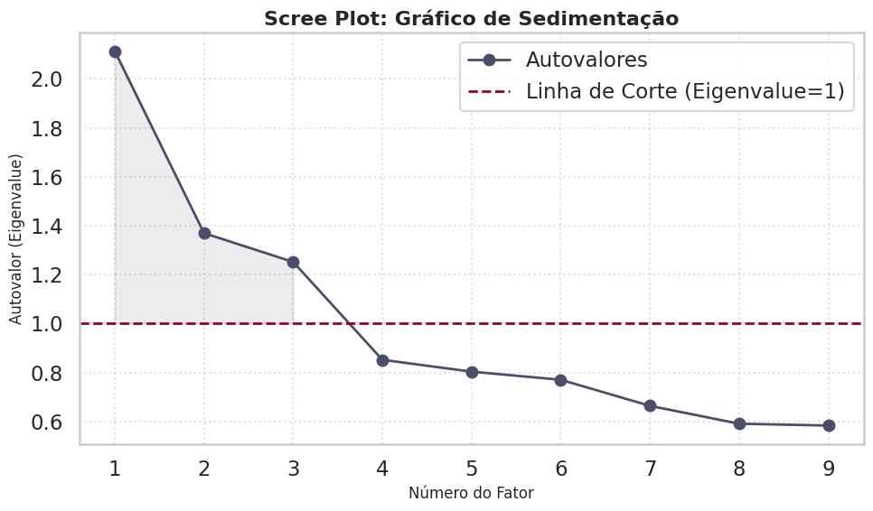

```
   ✅ Seguiremos a análise extraindo 3 fatores latentes.
```

```python
#@title 3. Determinação do Número de Fatores
Log.title("3. Determinação do Número de Fatores")

fa_pre = FactorAnalyzer(rotation=None, impute='drop')
fa_pre.fit(df_afe)
ev, v = fa_pre.get_eigenvalues()
n_fatores_kaiser = sum(ev > 1)

Log.section("Critério de Kaiser (Autovalores > 1)\n")
Log.info("Fatores Sugeridos", n_fatores_kaiser)

plt.figure(figsize=(10, 6))
plt.plot(range(1, len(ev)+1), ev, 'o-', linewidth=2, color='#4a4e69', label='Autovalores')
plt.axhline(y=1, color='#9a031e', linestyle='--', linewidth=2, label='Linha de Corte (Eigenvalue=1)')
plt.fill_between(range(1, n_fatores_kaiser+1), 1, ev[:n_fatores_kaiser], color='#4a4e69', alpha=0.1)

plt.title('Scree Plot: Gráfico de Sedimentação', fontsize=16, fontweight='bold')
plt.xlabel('Número do Fator', fontsize=12)
plt.ylabel('Autovalor (Eigenvalue)', fontsize=12)
plt.xticks(range(1, len(ev)+1))
plt.legend()
plt.grid(True, linestyle=':', alpha=0.6)
plt.tight_layout()
plt.show()

Log.success(f"Seguiremos a análise extraindo {n_fatores_kaiser} fatores latentes.")
```

### **Modelagem Final, Cargas Fatoriais e Comunalidades**

**O que estamos fazendo:** Rodamos a AFE final configurada com rotação Promax (Oblíqua) e o número de fatores definido anteriormente. Geramos o mapa de calor das cargas e a tabela de variância.

**Por que fazer:**

- **Rotação Promax:** Usada quando teoricamente os fatores podem se correlacionar (ex: quem está mais satisfeito com o salário tende a estar mais satisfeito com a empresa). Facilita a interpretação.
- **Cargas Fatoriais (Loadings):** Mostram a força da relação entre a pergunta e o fator. Cargas altas (>0.4) definem o significado do fator.
- **Comunalidades:** Mostram quanto da variância de cada pergunta é explicada pelo modelo. Valores baixos (<0.4) indicam perguntas que "não se encaixam" bem nos fatores criados.

[output not shown]

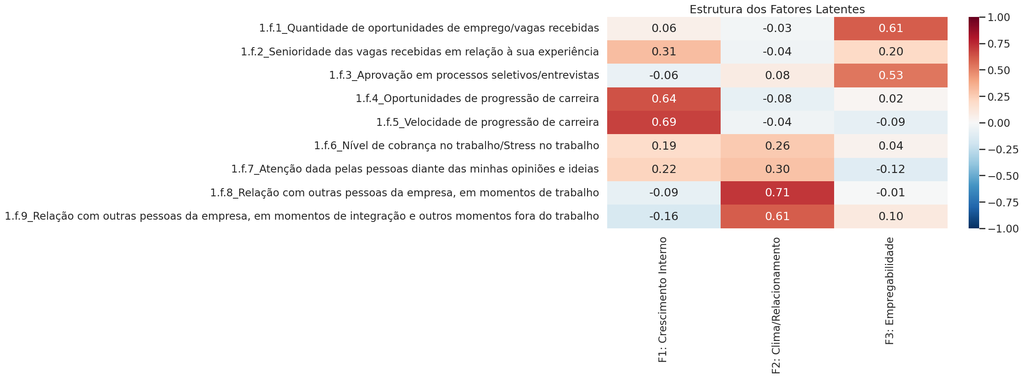

```
>>> Variância Explicada
```

|  | F1: Crescimento Interno | F2: Clima/Relacionamento | F3: Empregabilidade |
| --- | --- | --- | --- |
| SS Loadings | 109.83% | 105.03% | 72.91% |
| Prop. Variância | 12.20% | 11.67% | 8.10% |
| Variância Acumulada | 12.20% | 23.87% | 31.98% |

```
>>> Comunalidades (Qualidade da Variável no Modelo)
```

|  | Comunalidade |
| --- | --- |
| 1.f.6_Nível de cobrança no trabalho/Stress no trabalho | 0.10 |
| 1.f.2_Senioridade das vagas recebidas em relação à sua experiência | 0.14 |
| 1.f.7_Atenção dada pelas pessoas diante das minhas opiniões e ideias | 0.15 |
| 1.f.3_Aprovação em processos seletivos/entrevistas | 0.29 |
| 1.f.1_Quantidade de oportunidades de emprego/vagas recebidas | 0.37 |
| 1.f.9_Relação com outras pessoas da empresa, em momentos de integração e outros momentos fora do trabalho | 0.41 |
| 1.f.4_Oportunidades de progressão de carreira | 0.41 |
| 1.f.5_Velocidade de progressão de carreira | 0.48 |
| 1.f.8_Relação com outras pessoas da empresa, em momentos de trabalho | 0.52 |

```python
#@title 4. Resultados da Análise Fatorial
Log.title(f"4. Resultados Finais ({n_factors_kaiser} Fatores)")

fa_final = FactorAnalyzer(n_factors=n_factors_kaiser, rotation='promax')
fa_final.fit(df_afe)

factor_names = ['F1: Crescimento Interno', 'F2: Clima/Relacionamento', 'F3: Empregabilidade']

loadings = pd.DataFrame(fa_final.loadings_, index=df_afe.columns, columns=factor_names)

variance = pd.DataFrame(fa_final.get_factor_variance(),
                        index=['SS Loadings', 'Prop. Variância', 'Variância Acumulada'],
                        columns=factor_names)

comm_df = pd.DataFrame(fa_final.get_communalities(), index=df_afe.columns, columns=['Comunalidade'])

Log.section("Matriz de Cargas Fatoriais (Heatmap)")
plt.figure(figsize=(12, 6))
sns.heatmap(loadings, annot=True, cmap="RdBu_r", center=0, vmin=-1, vmax=1, fmt=".2f")
plt.title('Estrutura dos Fatores Latentes')
plt.show()

Log.section("Variância Explicada")
display(variance.style.format("{:.2%}").background_gradient(cmap='Greens', axis=1))

Log.section("Comunalidades (Qualidade da Variável no Modelo)")
display(comm_df.sort_values(by='Comunalidade', ascending=True)
        .style.format("{:.2f}").background_gradient(cmap='Reds', vmin=0, vmax=1))
```

### **Conclusão**

1. **Como eu cresço** (Fator Interno);
2. **Com quem eu trabalho** (Fator Social);
3. **Como o mercado me vê** (Fator Externo).

Isso sugere que ações de RH focadas apenas em "clima" (Fator 2) podem não ser suficientes para reter talentos que possuem alta empregabilidade (Fator 3) e não enxergam crescimento claro (Fator 1).

**Observação:** A variável de *Stress* apresentou baixa comunalidade, indicando que ela age como um fator independente: um profissional pode ter bom crescimento e bom clima, e ainda assim estar estressado.